# Intro to statistics with R

#### 6b. Linear regression

Linear regression is a method that can be used to quantitatively describe the relationship between a *dependent* variable and an *independent* variable. The terms can be thought of along the lines of:

```r
# "y depends on x"

# y is the dependent and x the independent value
# (you may also see "response variable" and "explanatory variable")

# In other words, x is used to predict (or "explain") y
```

The word *linear* is mentioned because the method assumes a linear relationship between *x* and *y*, meaning that it can be explained by a straight line. We can describe this using the following equation:

```r
# y = a + bx

# Where...
# a is a the intercept (the value of y when x = 0)
# b is the slope of the line
```

If you think of how experimental data would look as a scatter plot, the points likely wouldn’t fall perfectly onto a line drawn through them. The line passing through this “cloud of data” is called a *line of best fit* because it tries to minimize the distance between itself and individual data points.

To illustrate, let’s return to the `penguins` data. We imported it above as `penguinsdata` without missing values:

```r
#penguinsdata <- penguins |>
#  na.omit()

str(penguinsdata)
```

Let’s plot the measurements of penguin body mass and flipper length as a scatter plot and add a line of best fit using `geom_smooth`:

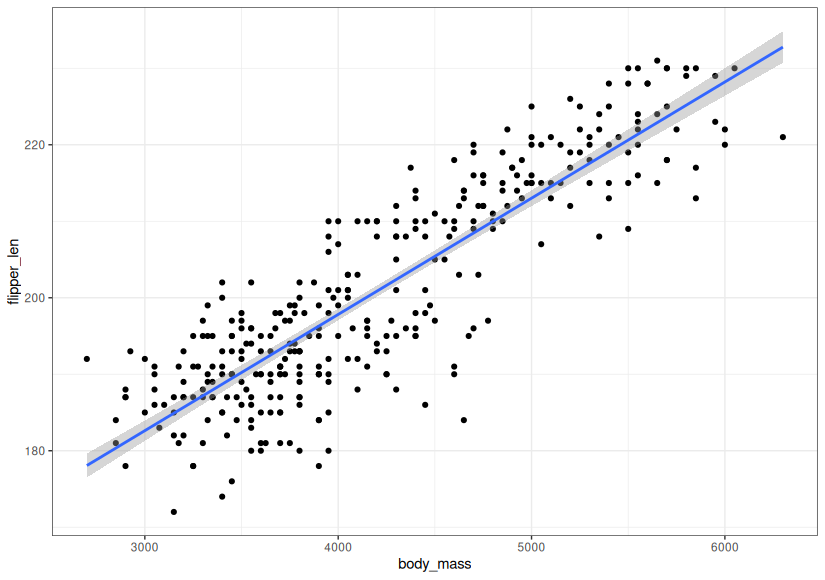

```r
ggplot(penguinsdata, aes(x = body_mass, y = flipper_len)) +
 geom_point() +
 geom_smooth(method = lm) + # this part is new...
 theme_bw()
```

By default, this also draws the 95% confidence interval (CI). A 95% CI of the mean is a range of values describing possible values that the mean could be. In other words, if we took many samples from the same population and calculated a 95% CI for each of these, we would expect the true population mean to be found within 95% of these values.

How about `method = lm` - what does it stand for? We are telling R that we’d like to use a *linear model*. Regression *models* the relationship between *x* and *y* with the regression equation describing that model (and the line of best fit being a visual representation of it). Linear models are common in hypothesis testing and come in different forms. The *t*-test is also a special case of a linear model!

To better understand the theory behind regression, there are a couple more points to cover before creating a model in R (outside `ggplot2`, that is).

- Regression and *correlation* are different things. Correlation analysis is another tool in the statistical toolbox that describes the relationship between two variables. However, it only describes if there is a positive or negative association between them (without predicting *y* from *x*).
- You may remember the concept of *residuals*. The scatter plot makes this easier to follow - we can think of a residual as the distance between a data point and the line of best fit. Residuals come to play when checking if our data meet the assumptions of a linear regression model.

To examine model diagnostics, we first need to create a model:

```r
penguins_lm <- lm(flipper_len ~ body_mass, data = penguinsdata)
```

The package `ggfortify` comes with the function `autoplot`, which can be used to create diagnostic plots. It generates four plots at once that are laid out as a panel. There is a lot of detail, but we’ll explore the plots one by one:

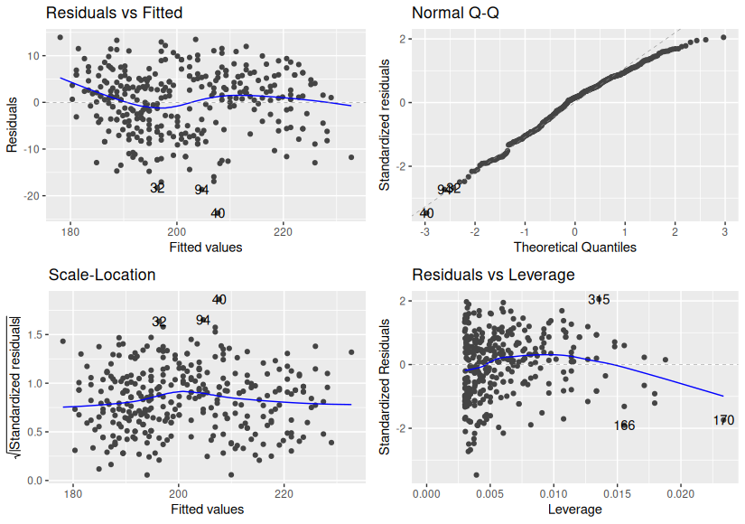

```r
autoplot(penguins_lm)
```

If everything looks acceptable, we can print out the model output using the `summary` function:

```r
summary(penguins_lm)

# Call:
# lm(formula = flipper_len ~ body_mass, data = penguinsdata)
#
# Residuals:
#     Min      1Q  Median      3Q     Max
# -23.698  -4.983   1.056   5.101  13.933
#
# Coefficients:
#              Estimate Std. Error t value Pr(>|t|)
# (Intercept) 1.370e+02  1.999e+00   68.56   <2e-16 ***
# body_mass   1.520e-02  4.667e-04   32.56   <2e-16 ***
# ---
# Signif. codes:  0 ‘***’ 0.001 ‘**’ 0.01 ‘*’ 0.05 ‘.’ 0.1 ‘ ’ 1
#
# Residual standard error: 6.847 on 331 degrees of freedom
# Multiple R-squared:  0.7621,  Adjusted R-squared:  0.7614
# F-statistic:  1060 on 1 and 331 DF,  p-value: < 2.2e-16
```

This generates a lot of information, most of which looks quite different to the *t*-test output. After the model call and some summary statistics on the residuals, we have information on the model *coefficients*.

```r
# Coefficients:
#              Estimate Std. Error t value Pr(>|t|)
# (Intercept) 1.370e+02  1.999e+00   68.56   <2e-16 ***
# body_mass   1.520e-02  4.667e-04   32.56   <2e-16 ***
# ---
# Signif. codes:  0 ‘***’ 0.001 ‘**’ 0.01 ‘*’ 0.05 ‘.’ 0.1 ‘ ’ 1
```

The coefficients correspond to the two constants in the model (the intercept and the slope). The `Estimate` column gives the solution to the equation describing our model, which could be written as:

```r
# (y = a + bx)
# flipper_len = 137 + 0.0152 ∗ body_mass
```

After columns with standard errors and test statistics, we see a column containing *P* values for the coefficients. The model shows that `body_mass` is positively associated with `flipper_len` (*P* < 0.001). The intercept is also significantly different from zero (which is nearly always the case).

The final part contains general information on the model:

```r
# Residual standard error: 6.847 on 331 degrees of freedom
# Multiple R-squared:  0.7621,  Adjusted R-squared:  0.7614
# F-statistic:  1060 on 1 and 331 DF,  p-value: < 2.2e-16
```

- The residual standard error describes the model fit (if it’s 0, then the model would describe the data perfectly).
- The multiple *R*-squared (*R*<sup>2</sup>) value gives the percentage of variance in the dependent variable predicted by the independent variable (in our case, 76%). This value is often reported as a measure of how well the model performs. The adjusted *R*<sup>2</sup> is used when there are many independent variables (it is a penalized version of the multiple *R*<sup>2</sup>).
- The last line describes the statistical significance of the model. The *F* statistic is based on a test where your model is compared against a model with no predictors. The *P* value is the overall *P* value for the model. We can see that our model is significant (meaning that it performs better than a model without predictors!).

Tip: to create a tidier output of the model summary, check the R package [broom](https://cran.r-project.org/web/packages/broom/vignettes/broom.html) and its functions `tidy()`, `augment()`, and `glance()`.

**Challenge**

If we are specifically interested in **correlation** of two variables, we can use the function `cor.test`. Let’s have a look at this in **Statistics Exercise Block 2** (~5 mins).

**Challenge**

When in linear regression the independent / explanatory variable consists of categorical data, linear regression becomes **Analysis of Variance (ANOVA)**, where the means of several groups are compared to variation within the groups. Otherwise the analysis proceeds similarly to our linear regression example above. The function `anova()` produces the ANOVA table used to present results of ANOVA. Another option is to use the functions `aov()` that runs `lm()` in the background to carry out the test and `summary()` to produce the ANOVA table.

Try running an ANOVA with `lm()` and `anova()` in **Statistics Exercise Block 3** (~5 mins).

#### 6c. Chi-squared test of independence

We will cover one more test: the Chi-squared (*χ*<sup>2</sup>) test of independence, also known as Pearson’s *χ*<sup>2</sup> test. This method can be used to determine if there is a correlation between categorical variables, such as names or labels. Specifically, it is used when you want to compare frequencies (counts) between groups. This is done by comparing the observed frequencies with a set of frequencies one would expect if there was no correlation between groups.

```r
mtcarsdata <- mtcars
head(mtcars)
```

The data set comes as a data frame with different car models as row names.

- The first variable we might be interested in is the type of engine (`vs`), which can be either V-shaped (`0`) or straight (`1`).
- There is also a column for the gear count (`gear`), ranging from three to five.

Let’s say we’d like to find out if there is an association between these two variables. How to go about it?

First we need to shape the data into a format suitable for the *χ*<sup>2</sup> test. To do this, let’s create a frequency table listing all the combinations we’re interested in. Such a table is also known as a *contingency table*.

Before creating the table, let’s make things easier to follow by replacing the numbers with labels. We can use a `dplyr` function called `recode`:

```r
mtcarsdata <- mtcarsdata |>
  mutate(vs = recode(vs,
                     "0" = "Vshaped",
                     "1" = "Straight"),
        gear = recode(gear,
                     "3" = "Three_gears",
                     "4" = "Four_gears",
                     "5" = "Five_gears"))
head(mtcarsdata)
```

We can create a contingency table using `table`:

```r
mtcarsdata_freqs <- table(mtcarsdata$vs, mtcarsdata$gear)
mtcarsdata_freqs

#           Five_gears Four_gears Three_gears
# Straight           1         10           3
# Vshaped            4          2          12
```

Now that the data are in the desired format, this is a good time to think about test assumptions. The *χ*<sup>2</sup> test is a non-parametric method that comes with the following requirements, aside from needing the data as counts:

- The groups must be mutually exclusive (the data should fit within a single level of each variable).
- Each subject should only contribute data to one cell (e.g. comparisons of the same individual at different times are not possible). Similarly, for paired-sample designs one would need to consider another test.
- Expected values should be 5 or above in at least 80% of the cells, and no cell should have an expected value of less than one.

Looking at the numbers we have in our table, especially the last assumption might give us something to think about. To have a look at the expected values, let’s run the test using `chisq.test`:

```r
mtcarsdata_chisq <- chisq.test(mtcarsdata_freqs)

# Warning message:
# In chisq.test(mtcarsdata_freqs) :
# Chi-squared approximation may be incorrect
```

We get a warning saying the approximation might be incorrect. We can extract the expected values from the object:

```r
round(mtcarsdata_chisq$expected, 2) # rounding to two decimals

#            Five_gears Four_gears Three_gears
# Straight         2.19       5.25        6.56
# Vshaped          2.81       6.75        8.44
```

The warning is because there are some cells in the contingency table that have an expected value below five. R is telling us that the test output might be biased due to a lack of data. Out of curiosity, we could still have a look at it:

```r
mtcarsdata_chisq

# Pearson's Chi-squared test

# data: mtcarsdata_freqs
# X-squared = 12.224, df = 2, p-value = 0.002216

# Could be an association between motor type and gear count...
```

With a small sample size like ours (and also with 2x2 contingency tables), an alternative test called the Fisher’s exact test may be more appropriate. We won’t cover the details, but running it is similar to performing a *χ*<sup>2</sup> analysis: `fisher.test(mtcarsdata_freqs)`. Although not always possible in the world of experimental science (let alone field studies), another option would be to gather more data!

**Note:** It is possible to correct for small sample sizes by typing `correct = TRUE` inside the `chisq.test` function call. This is called the Yates continuity correction and R uses it automatically when working with 2x2 contingency tables. However, this correction can be highly conservative.

#### 7. Further information

Choosing the most suitable statistical method, evaluating test diagnostics and how to best transform your data are all quite vast topics of their own. While an in-depth discussion of these is beyond the scope of the workshop, useful resources that might be helpful for self-study are the [R for Data Science](https://r4ds.had.co.nz/) e-book (accessible for free), [Getting Started with R: An Introduction for Biologists](https://global.oup.com/academic/product/getting-started-with-r-9780198787846?cc=fi&lang=en&), and [Modern Statistics with R](https://modernstatisticswithr.com/) (e-book accessible for free).